# EDA on Movies Dataset

### Review the movies datasets and perform Exploratory Data Analysis(EDA) to identify various corelation that exists within the columns. The data has been filtered for movies between 1900 & 2017

#### Lets print the header to quickly identify the various columns and their datatypes.

| tconst | titleType | primaryTitle | originalTitle | isAdult | startYear | endYear | runtimeMinutes | genres |
| --- | --- | --- | --- | --- | --- | --- | --- | --- |
| tt0000001 | short | Carmencita | Carmencita | 0 | 1894 | NA | 1 | Documentary,Short |

The total number of observations : 4,865,375 with 9 variables.

#### Movie summary by movie types

##### **tvEpisodes** are the highest numbers and it also accurate with the list of TV shows being released on Netfix on regular basis. But it was surprising to see **short** movies coming at second place where i was expecting **movies**.

So it does look like the future is with **tvEpisodes** where a storyboard is broken into multiple seasons and released year on year.

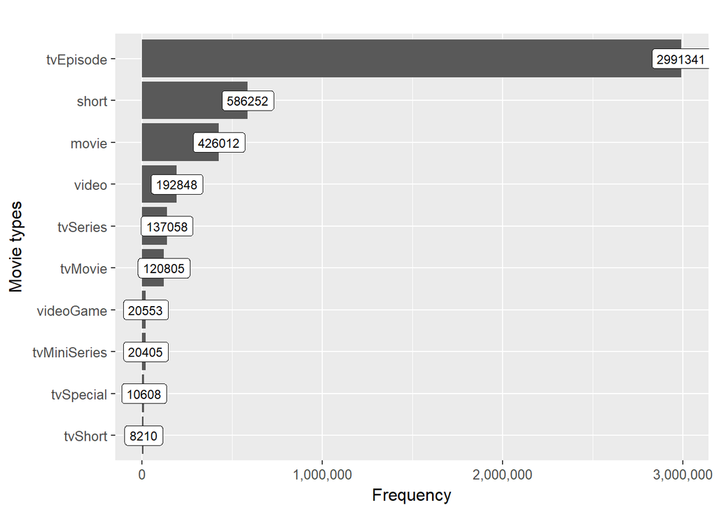

#### Movie summary by maturity

##### Maximum movies are having family viewership but the numbers of **Adult** movies are also huge.

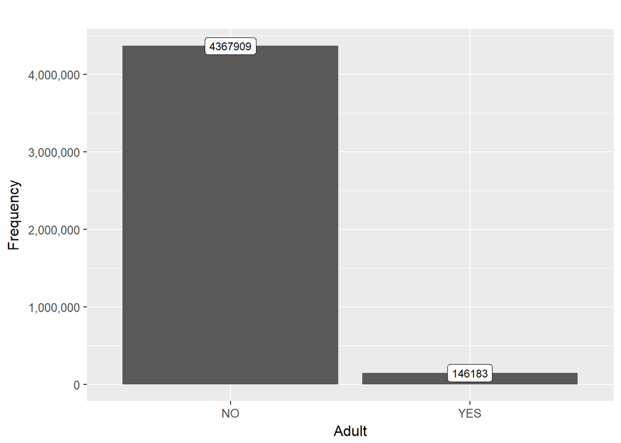

### Movie summary by age preference & movie types

##### **Adult** movies are primarily within video category while the non adult movies are spread across all types.

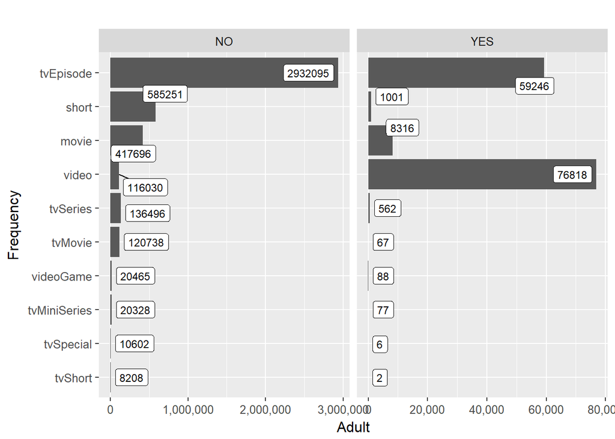

### Movie trends across the years

##### It has been a slow trend till 1990 while it rocketed up post 2000 owing to the internet usage and online service providers like Netflix which started around **1997**

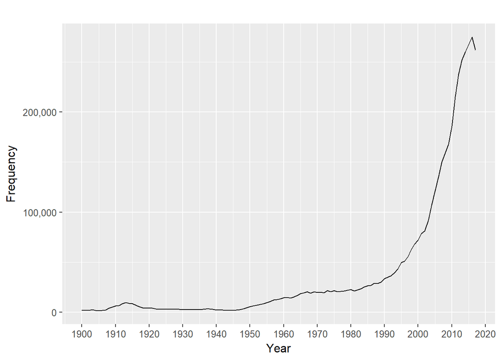

### Movie counts by year & movie type

##### While the rest of the movie types have relative smooth upward trend but its the **tvShort** movies that caught my eye. It did have a healthy up and downs all along and could be due to tight budgets in those early years or scarcity of crew for making a large scale movies.

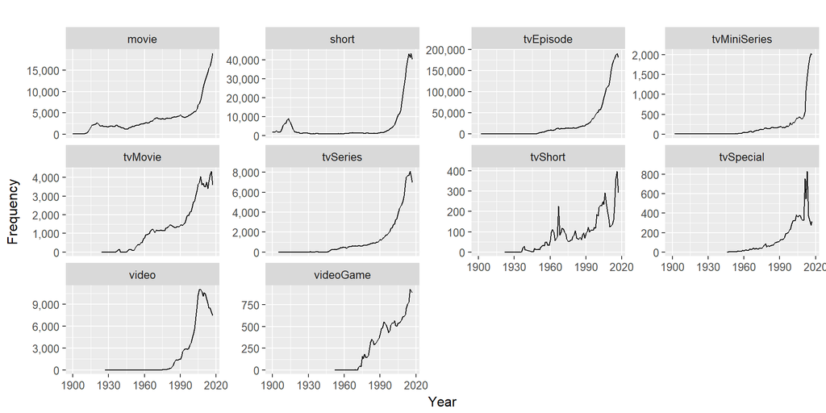

### Movie summary by year & age preference.

##### **Adult** movies have shown a sharp increase from late 1900 till date.

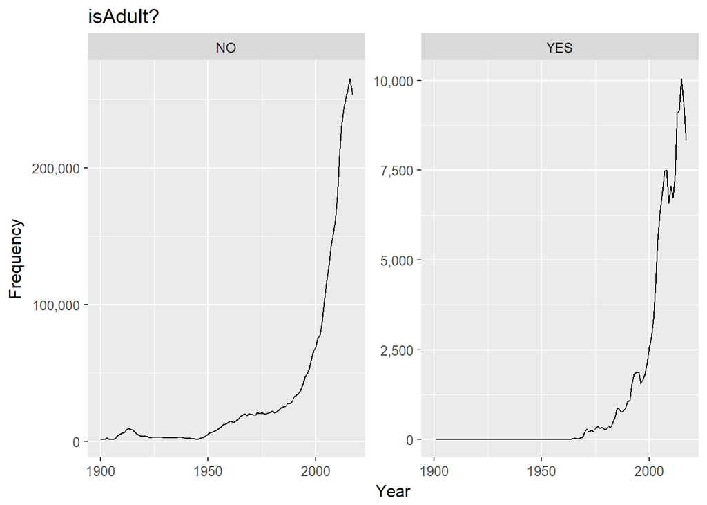

### Movies by genres, top 20

##### Never knew that **comedy** would be the number one volume.. ho ho haha !

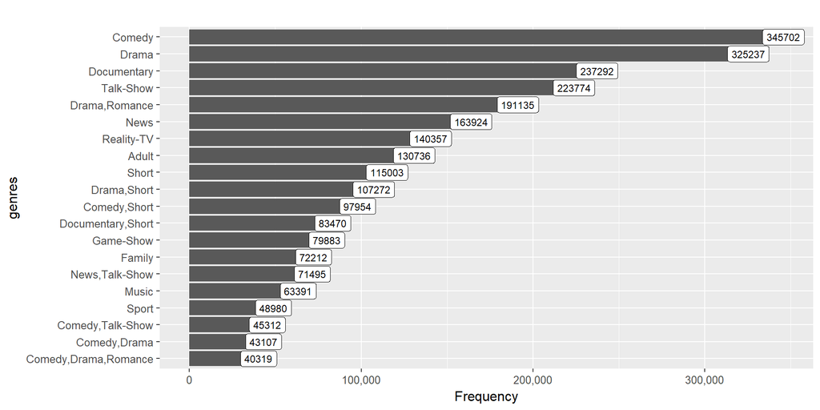

### Distribution of runtimeMinutes by titleType and sorted by median values.

| titleType | mean | median | min | lower | middle | upper | max |
| --- | --- | --- | --- | --- | --- | --- | --- |
| short | 13 | 11 | 0 | 7 | 11 | 18 | 1030 |
| tvShort | 21 | 22 | 1 | 10 | 22 | 30 | 105 |
| tvSeries | 46 | 30 | 1 | 26 | 30 | 60 | 8400 |
| tvEpisode | 39 | 30 | 0 | 23 | 30 | 47 | 1973 |
| tvMiniSeries | 113 | 55 | 1 | 30 | 55 | 174 | 1620 |
| videoGame | 109 | 57 | 1 | 23 | 57 | 100 | 1500 |
| video | 64 | 59 | 1 | 10 | 59 | 96 | 5700 |
| tvMovie | 75 | 70 | 1 | 50 | 70 | 91 | 5760 |
| tvSpecial | 129 | 80 | 1 | 60 | 80 | 120 | 125156 |
| movie | 87 | 88 | 1 | 72 | 88 | 99 | 14400 |

### Few movies that have very high runtimeMinutes

| tconst | titleType | primaryTitle | originalTitle | isAdult | startYear | endYear | runtimeMinutes | genres |
| --- | --- | --- | --- | --- | --- | --- | --- | --- |
| tt0466521 | tvSeries | The Sharing Circle | The Sharing Circle | 0 | 1991 | 2008 | 8400 | Documentary |
| tt2659636 | movie | Modern Times Forever | Modern Times Forever | 0 | 2011 | NA | 14400 | Documentary |
| tt5649726 | tvSpecial | Test Movie AKA: Worldwide | A Test Movie | 1 | 2017 | NA | 125156 | Adult |

#### On checking few of the high runtimeMinutes we find that movies like **Modern Times Forever** are some experimental movies that have comments like *The ever slow decay of Helsinki’s Stora Enso headquarters building*

#### **The Sharing Circle**, *is Canada’s longest running Aboriginal documentary television series. This unique program presents thirteen half-hour documentaries focused on current, relevant issues that are explored in traditional, spiritual ways. These fascinating and poignant stories offer an insightful and meaningful look at Aboriginal People, Indigenous Knowledge and Spiritual Practice.*